# Лабораторная_3

### Параметрические классификаторы для бинарной зависимой переменной (Y)

В данной задаче выполняются следующие пункты:

- построение модели логистической регрессии;
- построение модели линейного дискриминантного анализа (LDA);
- построение модели квадратичного дискриминантного анализа (QDA);
- построение ROC-кривой.

*Модели*: логистическая регрессия, LDA, QDA.  
*Данные*: сгенерированный набор случаев диабета у женщин индейского племени Пима PimaIndiansDiabetes{mlbench}.В наборе 768 наблюдений и 9 показателей:

- pregnant - количество беременностей;
- glucose - значения глюкозотолерантного теста;
- pressure - диастолическое давление;
- triceps - Толщина створки кожи трицепсов;
- insulin - инсулин в сыворотке крови;
- mass - индекс массы тела;
- pedigree - функция родословной диабета;
- age - возраст;
- diabetes - зависимая переменная,тест на диабет.(pos – наличие признака, neg – отсутствие)

# Пакеты:

```r
library('mlbench')
library('GGally')
library('MASS')
```

# Зададим ядро генератора случайных чисел и объём обучающей выборки.

```r
my.seed <- 123
train.percent <- 0.75
```

## Исходные данные: набор PimaIndiansDiabetes

```r
data(PimaIndiansDiabetes)
head(PimaIndiansDiabetes)
```

|  | pregnant | glucose | pressure | triceps | insulin | mass | pedigree | age | diabetes |
| --- | --- | --- | --- | --- | --- | --- | --- | --- | --- |
| 1 | 6 | 148 | 72 | 35 | 0 | 33.6 | 0.627 | 50 | pos |
| 2 | 1 | 85 | 66 | 29 | 0 | 26.6 | 0.351 | 31 | neg |
| 3 | 8 | 183 | 64 | 0 | 0 | 23.3 | 0.672 | 32 | pos |
| 4 | 1 | 89 | 66 | 23 | 94 | 28.1 | 0.167 | 21 | neg |
| 5 | 0 | 137 | 40 | 35 | 168 | 43.1 | 2.288 | 33 | pos |
| 6 | 5 | 116 | 74 | 0 | 0 | 25.6 | 0.201 | 30 | neg |

```r
str(PimaIndiansDiabetes)
```

```
## 'data.frame':    768 obs. of  9 variables:
##  $ pregnant: num  6 1 8 1 0 5 3 10 2 8 ...
##  $ glucose : num  148 85 183 89 137 116 78 115 197 125 ...
##  $ pressure: num  72 66 64 66 40 74 50 0 70 96 ...
##  $ triceps : num  35 29 0 23 35 0 32 0 45 0 ...
##  $ insulin : num  0 0 0 94 168 0 88 0 543 0 ...
##  $ mass    : num  33.6 26.6 23.3 28.1 43.1 25.6 31 35.3 30.5 0 ...
##  $ pedigree: num  0.627 0.351 0.672 0.167 2.288 ...
##  $ age     : num  50 31 32 21 33 30 26 29 53 54 ...
##  $ diabetes: Factor w/ 2 levels "neg","pos": 2 1 2 1 2 1 2 1 2 2 ...
```

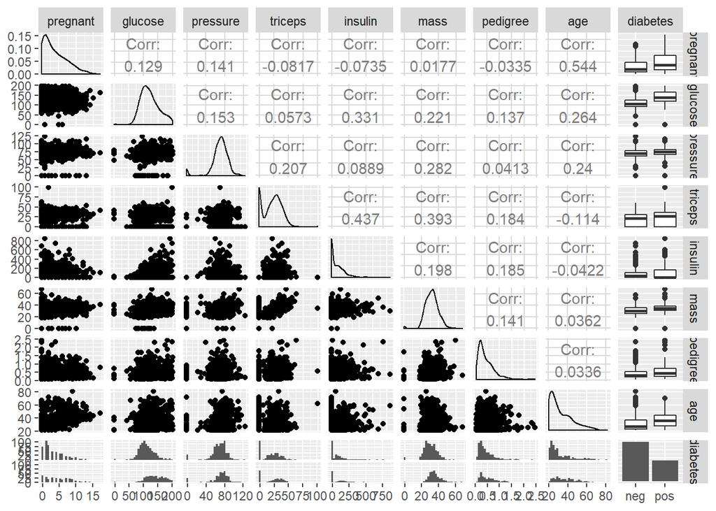

```r
ggpairs(PimaIndiansDiabetes)
```

## Отбираем наблюдения в обучающую выборку

```r
set.seed(my.seed)
inTrain <- sample(seq_along(PimaIndiansDiabetes$diabetes),
                  nrow(PimaIndiansDiabetes) * train.percent)
df <- PimaIndiansDiabetes[inTrain, ]
inTest <- -inTrain
df1 <- PimaIndiansDiabetes[inTest, ]
Факт <- df$diabetes
```

### Строим модели, чтобы спрогнозировать diabetes

## Логистическая регрессия

```r
#ОБУЧ
Факт <- df$diabetes
model.logit <- glm(diabetes ~ pregnant+glucose+pressure+insulin+mass+pedigree,
                   data = df,
                   family = 'binomial')

summary(model.logit)
```

```
##
## Call:
## glm(formula = diabetes ~ pregnant + glucose + pressure + insulin +
##     mass + pedigree, family = "binomial", data = df)
##
## Deviance Residuals:
##     Min       1Q   Median       3Q      Max
## -2.4744  -0.7325  -0.4257   0.7376   3.0608
##
## Coefficients:
##               Estimate Std. Error z value Pr(>|z|)
## (Intercept) -8.1165996  0.7850040 -10.340  < 2e-16 ***
## pregnant     0.1333870  0.0329149   4.052 5.07e-05 ***
## glucose      0.0380831  0.0042230   9.018  < 2e-16 ***
## pressure    -0.0117954  0.0059473  -1.983   0.0473 *
## insulin     -0.0016864  0.0009355  -1.803   0.0714 .
## mass         0.0829806  0.0158313   5.242 1.59e-07 ***
## pedigree     0.9141239  0.3377769   2.706   0.0068 **
## ---
## Signif. codes:  0 '***' 0.001 '**' 0.01 '*' 0.05 '.' 0.1 ' ' 1
##
## (Dispersion parameter for binomial family taken to be 1)
##
##     Null deviance: 741.30  on 575  degrees of freedom
## Residual deviance: 543.83  on 569  degrees of freedom
## AIC: 557.83
##
## Number of Fisher Scoring iterations: 5
```

```r
# прогноз: вероятности принадлежности классу 'pos' (диабет)
p.logit <- predict(model.logit, df, type = 'response')

Прогноз <- factor(ifelse(p.logit > 0.5, 2, 1),
                  levels = c(1,2),
                  labels = c('neg','pos'))



# матрица неточностей
conf.m <- table(Факт, Прогноз)
conf.m
```

```
##      Прогноз
## Факт  neg pos
##   neg 338  40
##   pos  89 109
```

```r
# чувствительность
conf.m[2, 2] / sum(conf.m[2, ])
```

```
## [1] 0.5505051
```

```r
# специфичность
conf.m[1, 1] / sum(conf.m[1, ])
```

```
## [1] 0.8941799
```

```r
# верность
sum(diag(conf.m)) / sum(conf.m)
```

```
## [1] 0.7760417
```

```r
#ТЕСТ
# фактические значения на обучающей выборке
Факт1 <- df1$diabetes


# Строим модели, чтобы спрогнозировать diabetes ---------------------------------

# Логистическая регрессия ======================================================
model.logit <- glm(diabetes ~ pregnant+glucose+pressure+insulin+mass+pedigree,
                   data = df1,
                   family = 'binomial')

summary(model.logit)
```

```
##
## Call:
## glm(formula = diabetes ~ pregnant + glucose + pressure + insulin +
##     mass + pedigree, family = "binomial", data = df1)
##
## Deviance Residuals:
##     Min       1Q   Median       3Q      Max
## -2.6049  -0.7413  -0.3945   0.6725   2.5140
##
## Coefficients:
##               Estimate Std. Error z value Pr(>|z|)
## (Intercept) -8.4673754  1.5726498  -5.384 7.28e-08 ***
## pregnant     0.1900799  0.0550239   3.455 0.000551 ***
## glucose      0.0313998  0.0070545   4.451 8.54e-06 ***
## pressure    -0.0113343  0.0099445  -1.140 0.254386
## insulin     -0.0006724  0.0017002  -0.396 0.692468
## mass         0.1065865  0.0352738   3.022 0.002514 **
## pedigree     1.1334963  0.6284842   1.804 0.071303 .
## ---
## Signif. codes:  0 '***' 0.001 '**' 0.01 '*' 0.05 '.' 0.1 ' ' 1
##
## (Dispersion parameter for binomial family taken to be 1)
##
##     Null deviance: 251.91  on 191  degrees of freedom
## Residual deviance: 179.99  on 185  degrees of freedom
## AIC: 193.99
##
## Number of Fisher Scoring iterations: 5
```

```r
# прогноз: вероятности принадлежности классу 'pos' (диабет)
p.logit <- predict(model.logit, df1, type = 'response')

Прогноз1 <- factor(ifelse(p.logit > 0.5, 2, 1),
                  levels = c(1,2),
                  labels = c('neg','pos'))



# матрица неточностей
conf.m <- table(Факт1, Прогноз1)
conf.m
```

```
##      Прогноз1
## Факт1 neg pos
##   neg 106  16
##   pos  26  44
```

```r
# чувствительность
conf.m[2, 2] / sum(conf.m[2, ])
```

```
## [1] 0.6285714
```

```r
# специфичность
conf.m[1, 1] / sum(conf.m[1, ])
```

```
## [1] 0.8688525
```

```r
# верность
sum(diag(conf.m)) / sum(conf.m)
```

```
## [1] 0.78125
```

## LDA

Отчёт по модели LDA содержит три раздела: априарные вероятности классов (Prior probabilities of groups), групповые средние объясняющих переменных (Group means) и коэффициенты линейной разделяющей границы (Coefficients of linear discriminants). У этой модели чувствительность аналогичная. Оценим модели LDA по обучающей и тестовой выборке.

```r
#ОБУЧ
model.lda <- lda(diabetes ~ pregnant+glucose+pressure+insulin+mass+pedigree,
                 data = df)

model.lda
```

```
## Call:
## lda(diabetes ~ pregnant + glucose + pressure + insulin + mass +
##     pedigree, data = df)
##
## Prior probabilities of groups:
##     neg     pos
## 0.65625 0.34375
##
## Group means:
##     pregnant  glucose pressure  insulin     mass  pedigree
## neg 3.412698 108.9762 67.82275 68.08466 30.39524 0.4359286
## pos 4.686869 140.3586 70.37879 96.26768 35.40303 0.5552879
##
## Coefficients of linear discriminants:
##                   LD1
## pregnant  0.100117141
## glucose   0.029603393
## pressure -0.009522332
## insulin  -0.001279075
## mass      0.058902695
## pedigree  0.660595244
```

```r
# прогноз: вероятности принадлежности классу 'pos' (диабет)
p.lda <- predict(model.lda, df,
                 type = 'response')
Прогноз <- factor(ifelse(p.lda$posterior[, 'pos'] > 0.5,
                         2, 1),
                  levels = c(1, 2),
                  labels = c('neg', 'pos'))

# матрица неточностей
conf.m <- table(Факт, Прогноз)
conf.m
```

```
##      Прогноз
## Факт  neg pos
##   neg 338  40
##   pos  89 109
```

```r
# чувствительность
conf.m[2, 2] / sum(conf.m[2, ])
```

```
## [1] 0.5505051
```

```r
# специфичность
conf.m[1, 1] / sum(conf.m[1, ])
```

```
## [1] 0.8941799
```

```r
# верность
sum(diag(conf.m)) / sum(conf.m)
```

```
## [1] 0.7760417
```

```r
#ТЕСТ
model.lda1 <- lda(diabetes ~ pregnant+glucose+pressure+insulin+mass+pedigree,
                 data = df1)

model.lda1
```

```
## Call:
## lda(diabetes ~ pregnant + glucose + pressure + insulin + mass +
##     pedigree, data = df1)
##
## Prior probabilities of groups:
##       neg       pos
## 0.6354167 0.3645833
##
## Group means:
##     pregnant  glucose pressure   insulin     mass  pedigree
## neg 2.942623 113.0902 69.30328  70.98361 30.02213 0.4105410
## pos 5.371429 143.8000 72.08571 111.84286 34.40571 0.5369571
##
## Coefficients of linear discriminants:
##                    LD1
## pregnant  1.525537e-01
## glucose   2.260197e-02
## pressure -8.302462e-03
## insulin   5.463192e-05
## mass      6.062622e-02
## pedigree  8.062268e-01
```

```r
# прогноз: вероятности принадлежности классу 'pos' (диабет)
p.lda1 <- predict(model.lda1, df1,
                 type = 'response')
Прогноз1 <- factor(ifelse(p.lda1$posterior[, 'pos'] > 0.5,
                         2, 1),
                  levels = c(1, 2),
                  labels = c('neg', 'pos'))

# матрица неточностей
conf.m <- table(Факт1, Прогноз1)
conf.m
```

```
##      Прогноз1
## Факт1 neg pos
##   neg 107  15
##   pos  27  43
```

```r
# чувствительность
conf.m[2, 2] / sum(conf.m[2, ])
```

```
## [1] 0.6142857
```

```r
# специфичность
conf.m[1, 1] / sum(conf.m[1, ])
```

```
## [1] 0.8770492
```

```r
# верность
sum(diag(conf.m)) / sum(conf.m)
```

```
## [1] 0.78125
```

Чувствительность на тестовой выборке значительно выше, чем на обучающей.

## QDA

Оценим модели QDA по обучающей и тестовой выборке.

```r
#ОБУЧ
model.qda <- qda(diabetes ~ pregnant+glucose+pressure+insulin+mass+pedigree, data = df)

model.qda
```

```
## Call:
## qda(diabetes ~ pregnant + glucose + pressure + insulin + mass +
##     pedigree, data = df)
##
## Prior probabilities of groups:
##     neg     pos
## 0.65625 0.34375
##
## Group means:
##     pregnant  glucose pressure  insulin     mass  pedigree
## neg 3.412698 108.9762 67.82275 68.08466 30.39524 0.4359286
## pos 4.686869 140.3586 70.37879 96.26768 35.40303 0.5552879
```

```r
# прогноз: вероятности принадлежности классу 'pos' (диабет)
p.qda <- predict(model.qda, df, type = 'response')
Прогноз <- factor(ifelse(p.qda$posterior[, 'pos'] > 0.5,
                         2, 1),
                  levels = c(1, 2),
                  labels = c('neg', 'pos'))

# матрица неточностей
conf.m <- table(Факт, Прогноз)
conf.m
```

```
##      Прогноз
## Факт  neg pos
##   neg 328  50
##   pos  89 109
```

```r
# чувствительность
conf.m[2, 2] / sum(conf.m[2, ])
```

```
## [1] 0.5505051
```

```r
# специфичность
conf.m[1, 1] / sum(conf.m[1, ])
```

```
## [1] 0.8677249
```

```r
# верность
sum(diag(conf.m)) / sum(conf.m)
```

```
## [1] 0.7586806
```

```r
#ТЕСТ
model.qda1 <- qda(diabetes ~ pregnant+glucose+pressure+insulin+mass+pedigree, data = df1)

model.qda1
```

```
## Call:
## qda(diabetes ~ pregnant + glucose + pressure + insulin + mass +
##     pedigree, data = df1)
##
## Prior probabilities of groups:
##       neg       pos
## 0.6354167 0.3645833
##
## Group means:
##     pregnant  glucose pressure   insulin     mass  pedigree
## neg 2.942623 113.0902 69.30328  70.98361 30.02213 0.4105410
## pos 5.371429 143.8000 72.08571 111.84286 34.40571 0.5369571
```

```r
# прогноз: вероятности принадлежности классу 'pos' (диабет)
p.qda1 <- predict(model.qda1, df1, type = 'response')
Прогноз1 <- factor(ifelse(p.qda1$posterior[, 'pos'] > 0.5,
                         2, 1),
                  levels = c(1, 2),
                  labels = c('neg', 'pos'))

# матрица неточностей
conf.m <- table(Факт1, Прогноз1)
conf.m
```

```
##      Прогноз1
## Факт1 neg pos
##   neg 104  18
##   pos  25  45
```

```r
# чувствительность
conf.m[2, 2] / sum(conf.m[2, ])
```

```
## [1] 0.6428571
```

```r
# специфичность
conf.m[1, 1] / sum(conf.m[1, ])
```

```
## [1] 0.852459
```

```r
# верность
sum(diag(conf.m)) / sum(conf.m)
```

```
## [1] 0.7760417
```

Чувствительность на тестовой выборке значительно выше, чем на обучающей.

## ROC-кривые (1)

Построим две ROC-кривые на одних осях и сравним качества прогноза моделей на обучающей выборке.

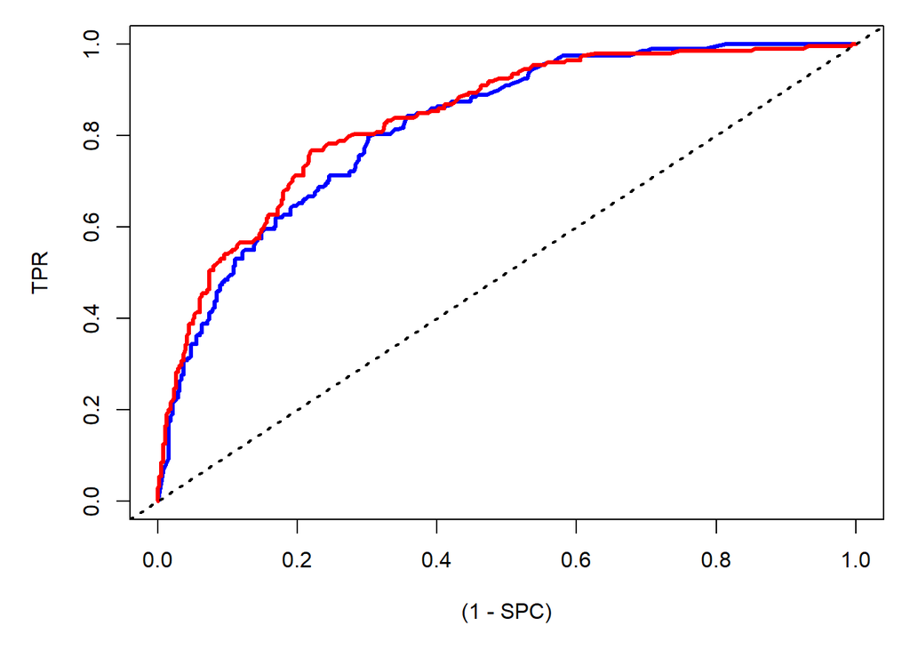

```r
# считаем 1-SPC и TPR для всех вариантов границы отсечения
x <- NULL    # для (1 - SPC)
y <- NULL    # для TPR

# заготовка под матрицу неточностей
tbl <- as.data.frame(matrix(rep(0, 4), 2, 2))
rownames(tbl) <- c('fact.neg', 'fact.pos')
colnames(tbl) <- c('predict.neg', 'predict.pos')

# цикл по вероятностям отсечения
for (p in seq(0, 1, length = 501)){
    # прогноз
    Прогноз <- factor(ifelse(p.qda$posterior[, 'pos'] > p,
                               2, 1),
                        levels = c(1, 2),
                        labels = c('neg', 'pos'))
    # фрейм со сравнением факта и прогноза
    df.compare <- data.frame(Факт = Факт, Прогноз = Прогноз)
    # заполняем матрицу неточностей
    # TN
    tbl[1, 1] <- nrow(df.compare[df.compare$Факт == 'neg' & df.compare$Прогноз == 'neg', ])

    # TP
    tbl[2, 2] <- nrow(df.compare[df.compare$Факт == 'pos' & df.compare$Прогноз == 'pos', ])

    # FP
    tbl[1, 2] <- nrow(df.compare[df.compare$Факт == 'neg' & df.compare$Прогноз == 'pos', ])

    # FN
    tbl[2, 1] <- nrow(df.compare[df.compare$Факт == 'pos' & df.compare$Прогноз == 'neg', ])


    # считаем характеристики
    TPR <- tbl[2, 2] / sum(tbl[2, ])
    y <- c(y, TPR)
    SPC <- tbl[1, 1] / sum(tbl[1, ])
    x <- c(x, 1 - SPC)
}
x1 <- NULL    # для (1 - SPC)
y1 <- NULL    # для TPR

# заготовка под матрицу неточностей
tbl1 <- as.data.frame(matrix(rep(0, 4), 2, 2))
rownames(tbl1) <- c('fact.neg', 'fact.pos')
colnames(tbl1) <- c('predict.neg', 'predict.pos')

# цикл по вероятностям отсечения
for (p in seq(0, 1, length = 501)){
  # прогноз
  Прогноз <- factor(ifelse(p.lda$posterior[, 'pos'] > p,
                           2, 1),
                    levels = c(1, 2),
                    labels = c('neg', 'pos'))
  # фрейм со сравнением факта и прогноза
  df.compare <- data.frame(Факт = Факт, Прогноз = Прогноз)
  # заполняем матрицу неточностей
  # TN
  tbl1[1, 1] <- nrow(df.compare[df.compare$Факт == 'neg' & df.compare$Прогноз == 'neg', ])

  # TP
  tbl1[2, 2] <- nrow(df.compare[df.compare$Факт == 'pos' & df.compare$Прогноз == 'pos', ])

  # FP
  tbl1[1, 2] <- nrow(df.compare[df.compare$Факт == 'neg' & df.compare$Прогноз == 'pos', ])

  # FN
  tbl1[2, 1] <- nrow(df.compare[df.compare$Факт == 'pos' & df.compare$Прогноз == 'neg', ])


  # считаем характеристики
  TPR1 <- tbl1[2, 2] / sum(tbl1[2, ])
  y1 <- c(y1, TPR1)
  SPC1 <- tbl1[1, 1] / sum(tbl1[1, ])
  x1 <- c(x1, 1 - SPC1)
}

# строим ROC-кривую
par(mar = c(5, 5, 1, 1))
# кривая
plot(x, y,
     type = 'l', col = 'blue', lwd = 3,
     xlab = '(1 - SPC)', ylab = 'TPR',
     xlim = c(0, 1), ylim = c(0, 1))
lines(x1,y1, type = 'l', col = 'red', lwd = 3,
      xlim = c(0, 1), ylim = c(0, 1))
# прямая случайного классификатора
abline(a = 0, b = 1, lty = 3, lwd = 2)
```

## ROC-кривые (2)

Построим две ROC-кривые на одних осях и сравним качества прогноза моделей на тестовой выборке.

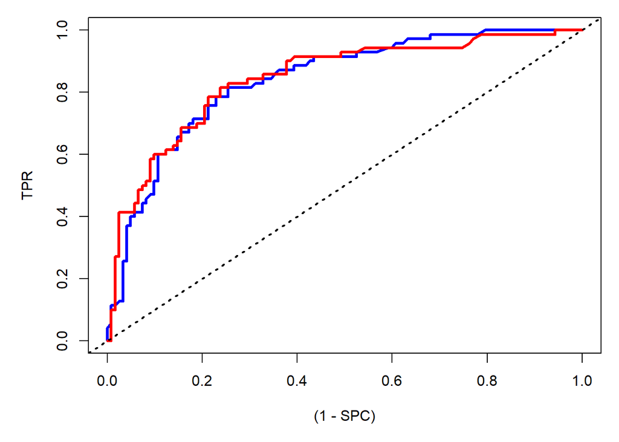

```r
# считаем 1-SPC и TPR для всех вариантов границы отсечения
x <- NULL    # для (1 - SPC)
y <- NULL    # для TPR

# заготовка под матрицу неточностей
tbl <- as.data.frame(matrix(rep(0, 4), 2, 2))
rownames(tbl) <- c('fact.neg', 'fact.pos')
colnames(tbl) <- c('predict.neg', 'predict.pos')

# цикл по вероятностям отсечения
for (p in seq(0, 1, length = 501)){
    # прогноз
    Прогноз1 <- factor(ifelse(p.qda1$posterior[, 'pos'] > p,
                               2, 1),
                        levels = c(1, 2),
                        labels = c('neg', 'pos'))
    # фрейм со сравнением факта и прогноза
    df1.compare <- data.frame(Факт1 = Факт1, Прогноз1 = Прогноз1)
    # заполняем матрицу неточностей
    # TN
    tbl[1, 1] <- nrow(df1.compare[df1.compare$Факт1 == 'neg' & df1.compare$Прогноз1 == 'neg', ])

    # TP
    tbl[2, 2] <- nrow(df1.compare[df1.compare$Факт1 == 'pos' & df1.compare$Прогноз1 == 'pos', ])

    # FP
    tbl[1, 2] <- nrow(df1.compare[df1.compare$Факт1 == 'neg' & df1.compare$Прогноз1 == 'pos', ])

    # FN
    tbl[2, 1] <- nrow(df1.compare[df1.compare$Факт1 == 'pos' & df1.compare$Прогноз1 == 'neg', ])


    # считаем характеристики
    TPR <- tbl[2, 2] / sum(tbl[2, ])
    y <- c(y, TPR)
    SPC <- tbl[1, 1] / sum(tbl[1, ])
    x <- c(x, 1 - SPC)
}
x1 <- NULL    # для (1 - SPC)
y1 <- NULL    # для TPR

# заготовка под матрицу неточностей
tbl1 <- as.data.frame(matrix(rep(0, 4), 2, 2))
rownames(tbl1) <- c('fact.neg', 'fact.pos')
colnames(tbl1) <- c('predict.neg', 'predict.pos')

# цикл по вероятностям отсечения
for (p in seq(0, 1, length = 501)){
  # прогноз
  Прогноз1 <- factor(ifelse(p.lda1$posterior[, 'pos'] > p,
                           2, 1),
                    levels = c(1, 2),
                    labels = c('neg', 'pos'))
  # фрейм со сравнением факта и прогноза
  df1.compare <- data.frame(Факт1 = Факт1, Прогноз1 = Прогноз1)
  # заполняем матрицу неточностей
  # TN
  tbl1[1, 1] <- nrow(df1.compare[df1.compare$Факт1 == 'neg' & df1.compare$Прогноз1 == 'neg', ])

  # TP
  tbl1[2, 2] <- nrow(df1.compare[df1.compare$Факт1 == 'pos' & df1.compare$Прогноз1 == 'pos', ])

  # FP
  tbl1[1, 2] <- nrow(df1.compare[df1.compare$Факт1 == 'neg' & df1.compare$Прогноз1 == 'pos', ])

  # FN
  tbl1[2, 1] <- nrow(df1.compare[df1.compare$Факт1 == 'pos' & df1.compare$Прогноз1 == 'neg', ])


  # считаем характеристики
  TPR1 <- tbl1[2, 2] / sum(tbl1[2, ])
  y1 <- c(y1, TPR1)
  SPC1 <- tbl1[1, 1] / sum(tbl1[1, ])
  x1 <- c(x1, 1 - SPC1)
}

# строим ROC-кривую
par(mar = c(5, 5, 1, 1))
# кривая
plot(x, y,
     type = 'l', col = 'blue', lwd = 3,
     xlab = '(1 - SPC)', ylab = 'TPR',
     xlim = c(0, 1), ylim = c(0, 1))
lines(x1,y1, type = 'l', col = 'red', lwd = 3,
      xlim = c(0, 1), ylim = c(0, 1))
# прямая случайного классификатора
abline(a = 0, b = 1, lty = 3, lwd = 2)
```

Чем ближе кривая к верхнему левому углу, тем выше предсказательная способность модели. Наоборот, чем меньше изгиб кривой и чем ближе она расположена к диагональной прямой, тем менее эффективна модель. Таким образом, можно сделать вывод о том, что ROC-кривые, построенные на обучающей и тестовой выборках для LDA(красные линии) оказались лучше, чем для QDA.